# Welcome to Safran TP 1

Every day, more than 80,000 commercial flights take place around the world, operated by hundreds of airlines. For all aircraft take-off weight exceeding 27 tons, a regulatory constraint requires companies to systematically record and analyse all flight data, for the purpose of improving the safety of flights. Flight Data Monitoring strives to detect and prioritize deviations from standards set by the aircraft manufacturers, the authorities of civil aviation in the country, or even companies themselves. Such deviations, called events, are used to populate a database that enables companies to identify and monitor the risks inherent to these operations.

This notebook is designed to let you manipulate real aeronautical data, provided by the Safran Group. It is divided in two parts: the first part deals with the processing of raw data, you will be asked to visualize the data, understand what variables require processing and perform the processing for some of these variables. The second part deals with actual data analysis, and covers some interesting problems. We hope to give you some insights of the data scientist job and give you interesting and challenging questions.

# Part 1: Data processing

## Loading the data

Load the **raw** data into the structure proposed below (the schema is given to you), using the code provided. The definition of the variables available is given here:

| var | description |
| --- | --- |
| TIME | elapsed seconds |
| LATP_1 | Latitude (°) |
| LONP_1 | Longitude (°) |
| RALT1 | Radio Altitude, sensor 1 (feet) |
| RALT2 | Radio Altitude, sensor 2 (feet) |
| RALT3 | Radio Altitude, sensor 3 (feet) |
| ALT_STD | Relative Altitude (feet) |
| HEAD | head (°) |
| PITCH | pitch (°) |
| ROLL | roll (°) |
| IAS | Indicated Air Speed (m/s) |
| N11 | speed N1 of the first engine (% of tr/min) |
| N21 | speed N2 of the first engine (% of tr/min) |
| N12 | speed N1 of the second engine (% of tr/min) |
| N22 | speed N2 of the second engine (% of tr/min) |
| AIR_GROUND | boolean, 0: ground, 1: air |

The sample rate is 1 Hz. You will be provided with `780` flight records. Each is a full record of a flight starting at the beginning of the taxi out phase and terminating at the end of the taxi in phase. Please be aware that due to side effects the very beginning of the record may be faulty. This is something to keep in mind when we will analyse the data.

**Note** : `TIME` represents the elapsed seconds from today midnight. You are not provided with an absolute time variable that would tell you the date and hour of the flights.

You will need some expertise about the signification of the variables. Latitude and longitude are quite straightforward. Head, Pitch and Roll are standards orientation angles, check this [image](https://i.stack.imgur.com/65EKz.png) to be sure. RALT* are coming from three different radio altimeters, they measure the same thing but have a lot of missing values and are valid only under a threshold altitude (around 5000 feet). Alt_std is the altitude measured from the pressure (it basically comes from a barometer), it is way less accurate that a radio altimeter but provides values for all altitudes. N1* and N2* are the rotational speeds of the engine sections expressed as a percentage of a nominal value. Some good links to check out to go deeper:

- [about phases of flight](http://www.fp7-restarts.eu/index.php/home/root/state-of-the-art/objectives/2012-02-15-11-58-37/71-book-video/parti-principles-of-flight/126-4-phases-of-a-flight)
- [pitch-roll-head](https://i.stack.imgur.com/65EKz.png)
- [about N** variables I](http://aviation.stackexchange.com/questions/14690/what-are-n1-and-n2)
- [about N** variables II](https://www.quora.com/Whats-N1-N2-in-aviation-And-how-is-the-value-of-100-N1-N2-determined)
- [how altimeters work](http://www.explainthatstuff.com/how-altimeters-work.html)
- [about runway naming](https://en.wikipedia.org/wiki/Runway#Naming)

```python
BASE_DIR = "/mnt/datasets/SAFRAN/data/"

from os import listdir
from os.path import isfile, join

import glob

import matplotlib as mpl
mpl.rcParams["axes.grid"] = True
import matplotlib.pylab as plt
%matplotlib inline

import numpy as np
import pandas as pd
pd.options.display.max_columns = 50

from datetime import datetime

# from haversine import haversine

def load_data_from_directory(DATA_PATH, num_flights):
    files_list = glob.glob(join(DATA_PATH, "*pkl"))
    print("There are %d files in total" % len(files_list))
    files_list = files_list[:num_flights]
    print("We process %d files" % num_flights)
    dfs = []
    p = 0
    for idx, f in enumerate(files_list):
        if idx % int(len(files_list)/10) == 0:
            print(str(p*10) + "%: [" + "#"*p + " "*(10-p) + "]", end="\r")
            p += 1
        dfs.append(pd.read_pickle(f))
    print(str(p*10) + "%: [" + "#"*p + " "*(10-p) + "]", end="\r")
    return dfs

# from IPython.core.display import HTML
# css = open('style-table.css').read()
# HTML('<style>{}</style>'.format(css))
```

Execute the cell below to load the data for part 1

```python
num_flights = 780
flights1 = load_data_from_directory(BASE_DIR + "part1/flights", num_flights)
for f in flights1:
    l = len(f)
    new_idx = pd.date_range(start=pd.Timestamp("now").date(), periods=l, freq="S")
    f.set_index(new_idx, inplace=True)
```

```
There are 780 files in total
We process 780 files
100%: [##########]
```

The data is loaded with pandas. Please take a look at the [pandas cheat sheet](https://github.com/pandas-dev/pandas/blob/master/doc/cheatsheet/Pandas_Cheat_Sheet.pdf) if you have any doubt. You are provided with 780 dataframes, each of them represents the records of the variables defined above during a whole flight.

`flights1` is a list where each item is a dataframe storing the data of one flight. There is no particular ordering in this list. All the flights depart from the same airport and arrive at the same airport. These airports are hidden to you and you will soon understand how.

For example `flights1[0]` is a dataframe, representing one flight.

```python
flights1[0].head(20)
```

|  | TIME | LATP_1 | LONP_1 | HEAD | PITCH | ROLL | IAS | RALT1 | RALT2 | RALT3 | ALT_STD | N11 | N21 | N22 | N12 | AIR_GROUND |
| --- | --- | --- | --- | --- | --- | --- | --- | --- | --- | --- | --- | --- | --- | --- | --- | --- |
| 2018-05-25 00:00:00 | 0 | 11.7731 | 33.3118 | 350.5 | -0.9 | -1.0 | 45.0 | NaN | NaN | -4.0 | -83.0 | 2.0 | 22.63 | 59.50 | 19.63 | 1.0 |
| 2018-05-25 00:00:01 | 1 | 11.7731 | 33.3118 | 350.5 | -0.9 | -1.0 | 45.0 | -4.0 | NaN | NaN | -83.0 | 2.0 | 23.75 | 59.38 | 19.75 | 1.0 |
| 2018-05-25 00:00:02 | 2 | 50.7330 | 21.2602 | 350.5 | -0.9 | -1.0 | 45.0 | NaN | NaN | -4.0 | -83.0 | 2.0 | 24.75 | 59.38 | 19.88 | 1.0 |
| 2018-05-25 00:00:03 | 3 | 48.0318 | 12.5277 | 350.1 | -0.9 | -1.0 | 45.0 | NaN | -5.0 | NaN | -84.0 | 3.0 | 25.63 | 59.50 | 20.00 | 1.0 |
| 2018-05-25 00:00:04 | 4 | 48.0318 | 12.5277 | 350.1 | -0.9 | -1.0 | 45.0 | NaN | NaN | -4.0 | -83.0 | 3.0 | 26.50 | 59.50 | 20.25 | 1.0 |
| 2018-05-25 00:00:05 | 5 | 48.0318 | 12.5277 | 349.8 | -0.9 | -1.0 | 45.0 | -4.0 | NaN | NaN | -84.0 | 3.0 | 27.13 | 59.38 | 20.50 | 1.0 |
| 2018-05-25 00:00:06 | 6 | 48.0318 | 12.5277 | 349.4 | -0.9 | -1.0 | 45.0 | NaN | NaN | -4.0 | -83.0 | 4.0 | 28.88 | 59.38 | 20.75 | 1.0 |
| 2018-05-25 00:00:07 | 7 | 48.0318 | 12.5277 | 349.4 | -0.9 | -1.0 | 45.0 | NaN | -5.0 | NaN | -82.0 | 5.0 | 30.50 | 59.38 | 20.63 | 1.0 |
| 2018-05-25 00:00:08 | 8 | 48.0318 | 12.5277 | 349.1 | -0.9 | -1.0 | 45.0 | NaN | NaN | -4.0 | -82.0 | 6.0 | 32.25 | 59.38 | 20.50 | 1.0 |
| 2018-05-25 00:00:09 | 9 | 48.0318 | 12.5277 | 349.4 | -0.9 | -1.0 | 45.0 | -4.0 | NaN | NaN | -82.0 | 6.0 | 34.00 | 59.38 | 20.38 | 1.0 |
| 2018-05-25 00:00:10 | 10 | 48.0316 | 12.5278 | 349.4 | -0.9 | -1.0 | 45.0 | NaN | NaN | -4.0 | -81.0 | 7.0 | 35.75 | 59.38 | 20.13 | 1.0 |
| 2018-05-25 00:00:11 | 11 | 48.0316 | 12.5278 | 349.8 | -0.9 | -1.0 | 45.0 | NaN | -5.0 | NaN | -82.0 | 8.0 | 37.38 | 59.38 | 20.00 | 1.0 |
| 2018-05-25 00:00:12 | 12 | 48.0316 | 12.5278 | 349.8 | -0.9 | -1.0 | 45.0 | NaN | NaN | -4.0 | -82.0 | 9.0 | 39.13 | 59.50 | 19.88 | 1.0 |
| 2018-05-25 00:00:13 | 13 | 48.0316 | 12.5278 | 349.8 | -0.9 | -1.0 | 45.0 | -4.0 | NaN | NaN | -82.0 | 10.0 | 40.88 | 59.38 | 19.50 | 1.0 |
| 2018-05-25 00:00:14 | 14 | 48.0316 | 12.5278 | 350.1 | -0.9 | -1.0 | 45.0 | NaN | NaN | -4.0 | -82.0 | 11.0 | 42.63 | 59.50 | 19.38 | 1.0 |
| 2018-05-25 00:00:15 | 15 | 48.0316 | 12.5278 | 350.5 | -0.9 | -1.0 | 45.0 | NaN | -4.0 | NaN | -82.0 | 12.0 | 44.50 | 59.50 | 19.38 | 1.0 |
| 2018-05-25 00:00:16 | 16 | 48.0316 | 12.5278 | 350.8 | -0.9 | -1.0 | 45.0 | NaN | NaN | -4.0 | -81.0 | 13.0 | 46.25 | 59.50 | 19.38 | 1.0 |
| 2018-05-25 00:00:17 | 17 | 48.0316 | 12.5280 | 351.5 | -0.9 | -1.0 | 45.0 | -4.0 | NaN | NaN | -82.0 | 14.0 | 48.00 | 59.50 | 19.38 | 1.0 |
| 2018-05-25 00:00:18 | 18 | 48.0316 | 12.5280 | 351.9 | -0.9 | -1.0 | 45.0 | NaN | NaN | -4.0 | -83.0 | 15.0 | 50.00 | 59.50 | 19.25 | 1.0 |
| 2018-05-25 00:00:19 | 19 | 48.0316 | 12.5280 | 352.2 | -0.9 | -1.0 | 45.0 | NaN | -4.0 | NaN | -83.0 | 16.0 | 51.88 | 59.38 | 19.38 | 1.0 |

You can select a column by indexing by its name.

```python
flights1[0]["PITCH"].describe()
```

```
count    7704.000000
mean        2.005101
std         2.378875
min        -2.800000
25%         0.500000
50%         1.800000
75%         2.800000
max        16.000000
Name: PITCH, dtype: float64
```

Use `iloc[]` to select by line number, either the whole dataframe to obtain all the variables or an individual series.

```python
flights1[0].iloc[50:60]
```

|  | TIME | LATP_1 | LONP_1 | HEAD | PITCH | ROLL | IAS | RALT1 | RALT2 | RALT3 | ALT_STD | N11 | N21 | N22 | N12 | AIR_GROUND |
| --- | --- | --- | --- | --- | --- | --- | --- | --- | --- | --- | --- | --- | --- | --- | --- | --- |
| 2018-05-25 00:00:50 | 50 | 48.0314 | 12.5278 | 352.9 | -0.9 | -1.0 | 45.0 | NaN | NaN | -4.0 | -82.0 | 20.0 | 59.38 | 59.25 | 19.63 | 1.0 |
| 2018-05-25 00:00:51 | 51 | 48.0314 | 12.5278 | 352.9 | -0.9 | -1.0 | 45.0 | NaN | -5.0 | NaN | -81.0 | 20.0 | 59.50 | 59.38 | 19.50 | 1.0 |
| 2018-05-25 00:00:52 | 52 | 48.0314 | 12.5278 | 352.9 | -0.9 | -1.0 | 45.0 | NaN | NaN | -4.0 | -81.0 | 19.0 | 59.50 | 59.38 | 19.50 | 1.0 |
| 2018-05-25 00:00:53 | 53 | 48.0314 | 12.5278 | 352.9 | -0.9 | -1.0 | 45.0 | -4.0 | NaN | NaN | -81.0 | 19.0 | 59.50 | 59.38 | 19.50 | 1.0 |
| 2018-05-25 00:00:54 | 54 | 48.0314 | 12.5278 | 352.9 | -0.9 | -1.0 | 45.0 | NaN | NaN | -4.0 | -81.0 | 20.0 | 59.50 | 59.38 | 19.50 | 1.0 |
| 2018-05-25 00:00:55 | 55 | 48.0314 | 12.5278 | 352.9 | -0.9 | -1.0 | 45.0 | NaN | -5.0 | NaN | -81.0 | 20.0 | 59.50 | 59.38 | 19.50 | 1.0 |
| 2018-05-25 00:00:56 | 56 | 48.0314 | 12.5278 | 352.9 | -0.9 | -1.0 | 45.0 | NaN | NaN | -4.0 | -81.0 | 20.0 | 59.50 | 59.38 | 19.63 | 1.0 |
| 2018-05-25 00:00:57 | 57 | 48.0316 | 12.5278 | 352.9 | -0.9 | -1.0 | 45.0 | -4.0 | NaN | NaN | -81.0 | 20.0 | 59.50 | 59.38 | 19.75 | 1.0 |
| 2018-05-25 00:00:58 | 58 | 48.0316 | 12.5278 | 352.9 | -0.9 | -1.0 | 45.0 | NaN | NaN | -4.0 | -81.0 | 20.0 | 59.50 | 59.38 | 19.75 | 1.0 |
| 2018-05-25 00:00:59 | 59 | 48.0316 | 12.5278 | 352.9 | -0.9 | -1.0 | 45.0 | NaN | -5.0 | NaN | -82.0 | 20.0 | 59.50 | 59.38 | 19.75 | 1.0 |

```python
flights1[0]["PITCH"].iloc[50:60]
```

```
2018-05-25 00:00:50   -0.9
2018-05-25 00:00:51   -0.9
2018-05-25 00:00:52   -0.9
2018-05-25 00:00:53   -0.9
2018-05-25 00:00:54   -0.9
2018-05-25 00:00:55   -0.9
2018-05-25 00:00:56   -0.9
2018-05-25 00:00:57   -0.9
2018-05-25 00:00:58   -0.9
2018-05-25 00:00:59   -0.9
Freq: S, Name: PITCH, dtype: float64
```

## Visualization

To perform monitoring of flights, it is necessary to clean up the data. To start, it is important to visualize the data that is available, in order to understand better their properties and the problems associated with them (noise, statistical characteristics, ladders, features and other values).

### Question 1 Visualize all the variables

For an arbitrary flight, for example `flights1[0]`, visualize all the variables. Would you rather use plot or scatter? Interpolate the data or not interpolate? Think about NaN values and how they are treated when we plot a series. Comment.

```python
import math

# merge the radio altitude
RALTS=zip(flights1[0]["RALT1"],flights1[0]["RALT2"],flights1[0]["RALT3"])
RALT=[]
for r in RALTS:
    x,y,z=r
    if math.isnan(x):
        if math.isnan(y):
            RALT.append(z)
        else:
            RALT.append(y)
    else:
        RALT.append(x)
print(RALT[0:10])
flights1[0].insert(7,"RALT",RALT)
```

```
[-4.0, -4.0, -4.0, -5.0, -4.0, -4.0, -4.0, -5.0, -4.0, -4.0]
```

```python
import matplotlib.pyplot as plt
```

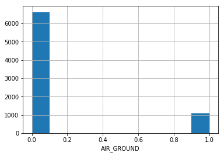

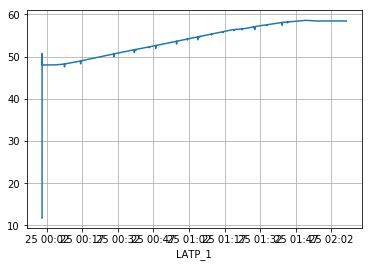

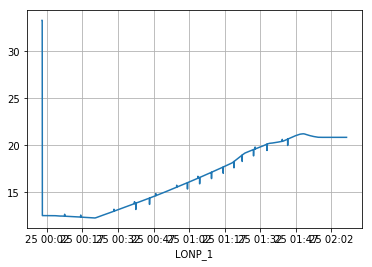

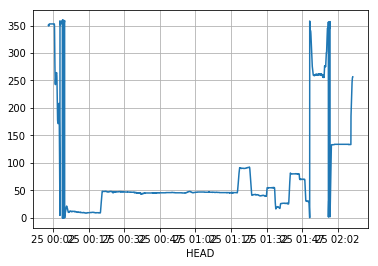

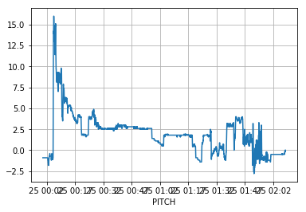

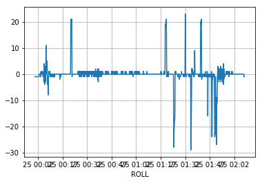

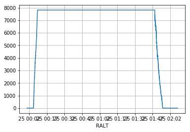

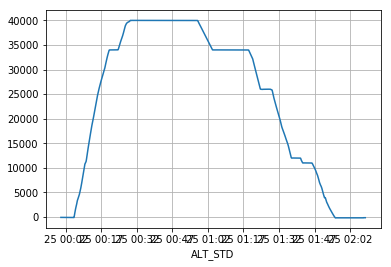

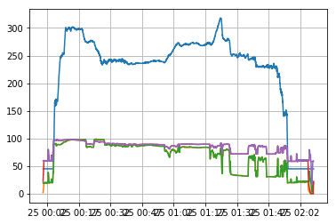

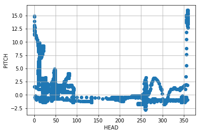

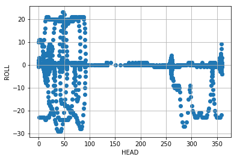

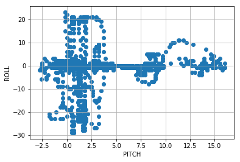

[7 more figures not shown]

```python
varsToHist=[
    "AIR_GROUND"
]
varsToPlot=[
    "LATP_1",
    "LONP_1",
    "HEAD",
    "PITCH",
    "ROLL",
    "RALT",
    "ALT_STD"
]
varsToPlotTogether=[
    ["IAS","N11","N12","N21","N22"]
]
varsToScatter=[
    ["HEAD","PITCH"],
    ["HEAD","ROLL"],
    ["PITCH","ROLL"],
    ["IAS","N11"],
    ["IAS","N12"],
    ["IAS","N21"],
    ["IAS","N22"],
    ["N11","N12"],
    ["N21","N22"],
    ["RALT","ALT_STD"]
]

for v in varsToHist:
    plt.hist(flights1[0][v])
    plt.xlabel(v)
    plt.show()

for v in varsToPlot:
    plt.plot(flights1[0][v])
    plt.xlabel(v)
    plt.show()

for vList in varsToPlotTogether:
    for v in vList:
        plt.plot(flights1[0][v])
    plt.show()

for v1,v2 in varsToScatter:
    plt.scatter(flights1[0][v1],flights1[0][v2])
    plt.xlabel(v1)
    plt.ylabel(v2)
    plt.show()
```

Your comment here:

Plot allows us to visualize one variable at a time. Scatter visualizes relations between variables. Both are useful: we'll plot most data but scatter the variables that seems correlated.

It seems that there will be a lot of missing data. Thus, interpolation seems to be a good way to fill the holes in the visualization.

We observe that the NaNs are produced by radio altitude sensors: when one sensor gives a value, the other give NaN. We merged them into one (relevant) variable `RALT`.

If it is interesting to see the variables for a given flight, it is more informative to view the set of values for all flights in order to understand what are the significant/normal values and what are those which are abnormal.

### Question 2 Visualize N21 variable for all flights

For the `N21` variable, for example, display all of the flights on the same figure. Use alpha parameter to add transparency to your plot. Is there any pattern? Comment the variabilities you observe.

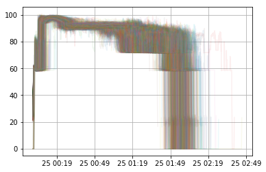

```python
for f in flights1:
    plt.plot(f["N21"],alpha=0.07)
plt.show()
```

Your comment here:

We can observe than all of the N21 variables follow the same progression among flights, eventhough the progression pattern is quite complex.

Some variables must be analyzed together, such as latitude and longitude, otherwise the visualization information will be incomplete, we could be missing something.

### Question 3 Visualize latitude against longitude for all flights

Display the trajectories (`LONP_1`, `LATP_1`) of the first 20 flights, that is `flights1[:20]`. What do you see? Keep in mind that the data during the beginning of the recording may be abnormal. What insight do you lose when you plot `LONP_1` against `LATP_1` ?

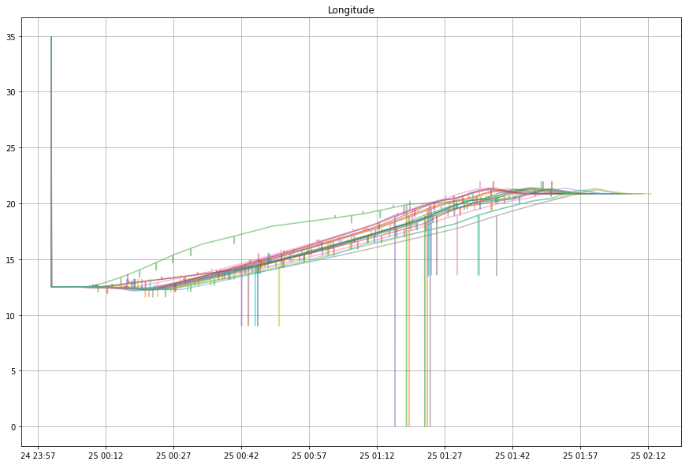

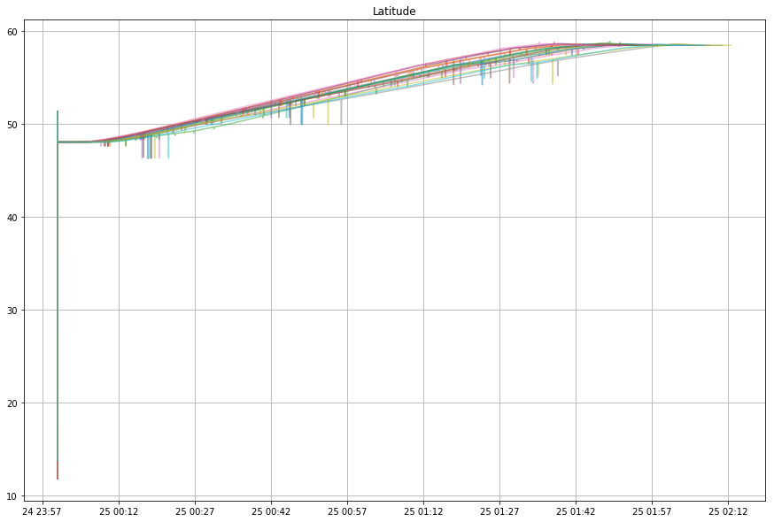

```python
plt.figure(figsize=(15,10))
for f in flights1[0:20]:
    plt.plot(f["LONP_1"],alpha=0.5)
plt.title("Longitude")
plt.show()

plt.figure(figsize=(15,10))
for f in flights1[0:20]:
    plt.plot(f["LATP_1"],alpha=0.5)
plt.title("Latitude")
plt.show()
```

Your comment here:

We ignore the beginning's spikes as they are physical errors. We can observe that these the longitude and the latitude move together. Let's confirm this with their correlation value:

```python
import numpy as np
```

```python
for f in flights1[0:20]:
    print(np.corrcoef(f["LONP_1"],f["LATP_1"])[0][1])
```

```
0.9469364779737812
0.9370910731388792
0.917905784454091
0.9431124942755206
0.9385966557418254
0.94376482388615
0.9456849132747623
0.9393868480327141
0.941603819057548
0.9437392694945415
0.9386879020368816
0.9384749742666213
0.9422811647666254
0.9425747802592778
0.9390555337973345
0.9424479797001769
0.9382615068260357
0.941243324260305
0.9439208086805766
0.9429945197709266
```

They are indeed very correlated.

Keep in mind that our goal is to understand the nature and the inherent problems of our data, and its features. Proceed with the visual analysis of the data, looking at different features.

### Question 4 Recap variables that require pre-processing

Based on your observations as for now, what are the variables requiring processing? For each of these variables, specify the necessary pre-processing required prior to perform data analysis.

Your answer here:

We already processed the radio altitudes by merging them thus deleting all the NaNs - see above.

The latitude and the longitude give aberrant results at the beginning. We set the first values to the first non-faulty value, which arrive at 3 (see below).

```python
for i in range(10):
    firstNormalValue=0
    while flights1[i]["LONP_1"][firstNormalValue]<10 or flights1[i]["LONP_1"][firstNormalValue]>15:
        firstNormalValue+=1
    # print(firstNormalValue,flights1[i]["LONP_1"][firstNormalValue:firstNormalValue+5])
for i in range(10):
    firstNormalValue=0
    while flights1[i]["LATP_1"][firstNormalValue]<10 or flights1[i]["LATP_1"][firstNormalValue]>15:
        firstNormalValue+=1
    # print(firstNormalValue,flights1[i]["LATP_1"][firstNormalValue:firstNormalValue+5])

# The first non-faulty values arrive at index 3
for i in range(len(flights1)):
    for j in range(3):
        flights1[i]["LONP_1"][j]=flights1[i]["LONP_1"][3]
        flights1[i]["LATP_1"][j]=flights1[i]["LATP_1"][3]
```

We also notice some spikes in the longitude and latitude values, which would mean that the plane moves very fast toward the north or the south then comes back, or represent acquisition errors. They are of course acquisition errors and need to be deleted.

[figure not shown]

```python
plt.plot([abs(flights1[0]["LONP_1"][j]-flights1[0]["LONP_1"][j-1]) for j in range(1,len(flights1[0]["LONP_1"])-1)])
plt.title("difference between consecutive values - shows that a difference > 0.02 is an error")
plt.show()

for i in range(20):
    diff=flights1[i]["LONP_1"].diff()
    for j in range(1,len(diff)-1):
        if abs(diff[j])>0.2:
            flights1[i]["LONP_1"][j]=(flights1[i]["LONP_1"][j+1]+flights1[i]["LONP_1"][j-1])/2
```

[figure not shown]

```python
plt.plot([abs(flights1[0]["LATP_1"][j]-flights1[0]["LATP_1"][j-1]) for j in range(1,len(flights1[0]["LATP_1"])-1)])
plt.title("difference between consecutive values - shows that a difference > 0.02 is an error")
plt.show()

for i in range(20):
    diff=flights1[i]["LATP_1"].diff()
    for j in range(1,len(diff)-1):
        if abs(diff[j])>0.2:
            flights1[i]["LATP_1"][j]=(flights1[i]["LATP_1"][j+1]+flights1[i]["LATP_1"][j-1])/2
```

Note that an important variable processing is the one of the head angle. It sometimes brutally shifts from around 360 to 0, which is analysed as a big head angle shift but actually represents a small angle shift. We don't have time to do the necessary processing, but it would be relevant to process the head angle data according to this observation.

It is important to undestand the links between variables, to understand how a system works.

### Question 5 Correlation between variables

Compute the correlation of each normalized variables with any others for one flight. Compute delay and max value for each pair of variables. What happens if you do not normalize ? What are the most correlated variables or group of variables ? Can you comment about the delay between variables ?

```python
from scipy import signal
def correlation(x,y):

    all_correlations = signal.correlate(x,y)
    maximum_correlation = np.max(all_correlations)
    delay = np.argmax(all_correlations)-x.shape[0]+1
    return maximum_correlation, delay
```

```python
flight=flights1[0]

correlation_val=[[0 for i in range (len(flight.columns))] for j in range (len(flight.columns)) ]
delay_val=[[0 for i in range (len(flight.columns))] for j in range (len(flight.columns)) ]

data_norm={}
for c in flight.columns:
    if c not in ["RALT1","RALT2","RALT3"]:
        data_norm[c]=[d/flight[c].sum() for d in flight[c]]
flight_norm=pd.DataFrame(data=data_norm)
for c in flight_norm.columns:
    for i in range(len(flight_norm[c])):
        if math.isnan(flight_norm[c][i]):
            flight_norm[c][i]=0
```

```python
cors=[[0 for i in range(14)] for j in range(14)]
delays=[[0 for i in range(14)] for j in range(14)]

for i in range(14):
    for j in range(14):
        ci=flight_norm.columns[i]
        cj=flight_norm.columns[j]
        cors[i][j],delays[i][j]=correlation(flight_norm[ci],flight_norm[cj])
```

```python
import seaborn as sns
```

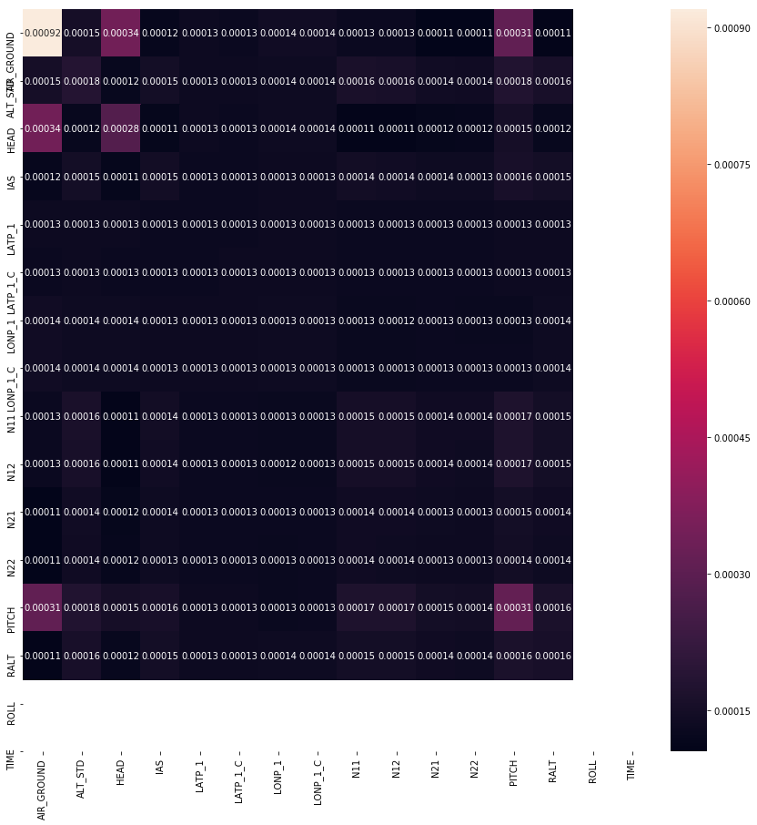

```python
plt.figure(figsize=(15,15))
sns.heatmap(cors,annot=True,yticklabels=flight_norm.columns,xticklabels=flight_norm.columns)
```

The correlation is calculated with the cross-correlation method which computes a value based on the area under the curves of some convolution. Had the data been not normalized, we could have had a high correlation between two uncorrelated variables just because their values are high, which is not a relevant correlation measure.

The most correlated values are the following:

- `AIR_GROUND`-`PITCH`: If the plane is on the ground, its pitch doesn't change because it stays horizontal
- `AIR_GROUND`-`HEAD`: during the taxi, the plane turns horizontally a lot, but on air it is likely to stay in one direction

We expected the latitude and the longitude to be highly correlated, as explained in the question 3, however, the correlation value shown here is normal, which is weird. The latitude or longitude values input in the heatmap might be faulty.

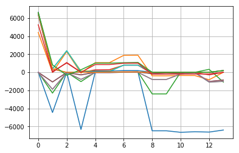

```python
plt.plot(delays)
plt.show()
```

Your comment here:

## Pre-processing

Data pre-processing is essential, in order to separate the errors due to measurement from "normal" data variability, which is representative of the phenomenon that interests us.

### Question 6 Smooth and filter out abnormal data in trajectories (LATP_1 and LONP_1)

Filter the flight trajectories (`LATP_1` and `LONP_1` variables). You can focus on the first 20 flights, that is `flights1[:20]`. Display the trajectories before and after smoothing.

Note that a first filtering of the latitude and longitude data has been done above.

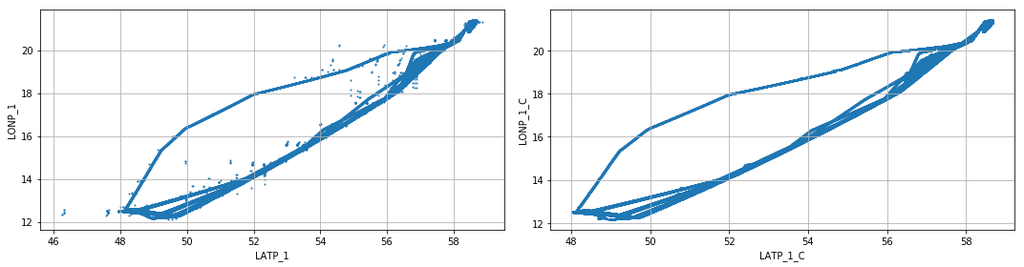

```python
# this is a template code, fill in the blanks, or use your own code

# Only work with the first few flights
fs = flights1[:20]

# Set up the figure to plot the trajectories before (ax0) and after smoothing (ax1)
fig, axarr = plt.subplots(1, 2)
fig.set_figwidth(15)
ax0, ax1 = axarr

for f in fs:
    f["LATP_1_C"] = f.LATP_1.rolling(window=40).mean() # FILL IN THE BLANKS
    f["LONP_1_C"] = f.LONP_1.rolling(window=40).mean() # FILL IN THE BLANKS

for f in fs:
    f.plot(kind="scatter", x="LATP_1", y="LONP_1", s=1, ax=ax0) # plot raw trajectory
    f.plot(kind="scatter", x="LATP_1_C", y="LONP_1_C", s=1, ax=ax1) # plot smoothed trajectory


fig.tight_layout()
```

### Question 7 Pre-process HEAD, get rid off discontinuities

Angles are special variables because they "cycle" over their range of values. The `HEAD` variable shows artificial discontinuities: your goal is to eliminate (filter out) such discontinuities. The angle may no longer be between 0 and 360 degrees after the transformation but it will come very handy for some analysis later. Display the data before and after transformation. You can focus on one flight, for example `flights1[0]`.

```python
for i in range(1,len(flights1[0]["HEAD"])):

    print("progression: {}%".format(100*i/len(flights1[0]["HEAD"])))
    if flights1[0]["HEAD"][i]-flights1[0]["HEAD"][i-1]>350:
        for j in range(i,len(flights1[0]["HEAD"])):
            flights1[0]["HEAD"][j]-=360
    if flights1[0]["HEAD"][i]-flights1[0]["HEAD"][i-1]<350:
        for j in range(i,len(flights1[0]["HEAD"])):
            flights1[0]["HEAD"][j]+=360

plt.plot(flights1[0]["HEAD"])
plt.show()
```

Your comment here:

The plot of the unmodified `HEAD` data is done above, at the question 1.

The script just above taks too much time to end before submitting our lab (a few hours of computing), but it shall work (eventually).

### Question 8 All data on the same time base

When we make an analysis, it is important to have the maximum of information. However, for any flight, you can see that there is three RALT (`RALT1`, `RALT2`, `RALT3`). They are not at the same sampling rate. Use interpolation on one flight, for example `flights1[0]`,to have them at the same sampling rate of 1Hz. Then, merge your results. Can you comment on the method you used ?

```python
from scipy import interpolate
# your code goes here ...
```

Your comment here:

We already merged the `RALTx` values into `RALT`.

# Part 2: Analysis

We now turn to the data analysis task. In this part, we will use a **clean** dataset, which has been prepared for you; nevertheless, the functions you developed in the first part of the notebook can still be used to visualize and inspect the new data. Next, we display the schema of the new dataset you will use:

| var | description |
| --- | --- |
| TIME | elapsed seconds |
| **LATP_C** | **Latitude (°), Corrected** |
| **LONP_C** | **Longitude (°), Corrected** |
| **RALT_F** | **Radio Altitude (feet), Fusioned** |
| **ALT_STD_C** | **Relative Altitude (feet), Corrected** |
| **HEAD_C** | **head (°), Corrected** |
| **HEAD_TRUE** | **head (°), without discontinuities** |
| **PITCH_C** | **pitch (°), Corrected** |
| **ROLL_C** | **roll (°), Corrected** |
| **IAS_C** | **Indicated Air Speed (m/s), Corrected** |
| N11 | speed N1 of the first engine (% of tr/min) |
| N21 | speed N2 of the first engine (% of tr/min) |
| N12 | speed N1 of the second engine (% of tr/min) |
| N22 | speed N2 of the second engine (% of tr/min) |
| AIR_GROUND | status in the air (Boolean) |

Execute the cell below to load the data for part 2

```python
num_flights = 780
flights2 = load_data_from_directory(BASE_DIR + "part2/flights/", num_flights)
for f in flights2:
    l = len(f)
    new_idx = pd.date_range(start=pd.Timestamp("now").date(), periods=l, freq="S")
    f.set_index(new_idx, inplace=True)
```

```
There are 780 files in total
We process 780 files
```

In this part, we will try to modelize a time series with simple models. In particular, we will look at the landing, and the N1 variable.

First, look at the variables for the flight 0, by executing the following code.

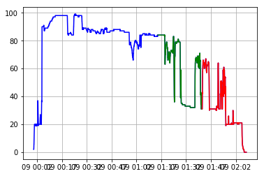

```python
plt.plot(flights2[0]['N11'], 'b')
index_start = 4500
tomodel = flights2[0]['N11'][index_start:index_start+1600]
topredict = flights2[0]['N11'][index_start+1600:index_start+3600]
plt.plot(tomodel, 'g')
plt.plot(topredict, 'r')
```

### Question 9 Modelization of time series

Is it stationary ? The augmented Dickey-Fuller test is a popular test to test the null hypothesis that a time series sample is non-stationary. Use this test to confirm what you observed.

```python
import scipy.stats.stats as stats
from statsmodels.tsa.stattools import adfuller
# your code goes here




DFtest_brut = ...
print('Augmented D-F test before detrending:')
print('p-value = ' + str(DFtest_brut))
```

[output not shown]

Your comment goes here ...

### Question 10 Modelization of time series

We may want to detrend the time serie. Fit a polynom or order 3 to the sequence `tomodel`, remove the trend and look at the Dickey-Fuller test again. Should you have used an higher degree polynomial? What would be the issue of a high degree polynomial when trying to do prediction of future sample?

```python
from sklearn.preprocessing import PolynomialFeatures
from sklearn.linear_model import LinearRegression
from sklearn.pipeline import Pipeline
# Your code goes here

DFtest_corrected
print('Augmented D-F test after detrending:')
print('p-value = ' + str(DFtest_corrected))
```

[output not shown]

Your comment goes here...

### Question 11 Prediction using polynomial

We want to predict what will be our next N11 in the next time steps. Use the polynom to predict the end of `tomodel`. Compare to `topredict`. What can you say ? What could you do to improve your prediction ?

```python
# Your code goes here
```

Your comment goes here...

We will now see if we can model the time series using auto-regressive / moving-average models. The **ARIMA** technique (Auto-Regressive Integrated Moving Average) allows modeling and forecasting of time series. The parameters of an ARIMA model are often noted (p,d,q) where:

- p is the number of auto-regressive terms (AR), e.g. if p=3, x(t) will be determined from x(t-1), x(t-2) and x(t-3)
- d is the number of differences to take before obtaining a stationary time series
- q is the number of moving average (MA) terms.

Autocorrelation (ACF) and partial autocorrelation (PACF) plots are a usefull tool to identify the values for *p* and *q*. The autocorrelation describes the correlation of observations with observations at previous time steps (or lags). Partial autocorrelation does the same thing but for lag *k* removes the effect of correlations due to the terms at shorter lags.

Plot the ACF and PACF of the time series.

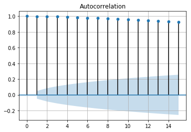

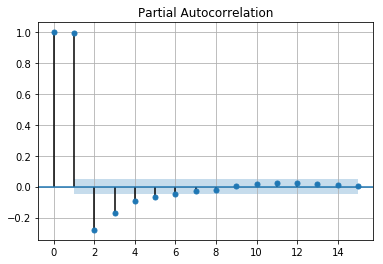

```python
from statsmodels.graphics.tsaplots import plot_acf
from statsmodels.graphics.tsaplots import plot_pacf
plot_acf(tomodel,lags=15)
plt.show()
plot_pacf(tomodel,lags=15)
plt.show()
```

On thoses plots you can observe blue shaded regions, those are confidence interevals (set to a 95% default value). Values of ACF or PACF outside of this region are likely to be correlations and not noise.

Observe the shape of the two plots:

[output not shown]

This is the sign of an auto-regressive AR(5) process.

To sum up:

```
the signal is not stationary, so we can try to have d=1
it seems to be an AR(5) process so p=5 and q=0
```

### Question 12 Prediction using ARIMA

Now, train an ARIMA(5,1,0) model on the data, and then, use it to predict the next steps of `tomodel`. Compare it to `topredict`

```python
from statsmodels.tsa.arima_model import ARIMA
from scipy.stats import probplot

ARmodel = ARIMA(#complete)
ARfitres = ARmodel.fit(trend='nc')


residuals = pd.DataFrame(ARfitres.resid)
residuals.plot()
plt.show()

probplot(ARfitres.resid, dist='norm',plot=plt)
plt.show()

plot_acf(ARfitres.resid,lags=15)
plt.show()

print(residuals.describe())
```

[output not shown]

```python
model = ARIMA(#complete)
model_res = model.fit(disp=0)
newval = model_res.forecast(len(topredict))[0]

plt.plot(X[:len(tomodel)],tomodel)
plt.plot(X[len(tomodel):],topredict)
plt.plot(X[len(tomodel):],newval)
plt.show()
```

[output not shown]

We tried two models. We now want to compare them in a more scientific way, to select the best model.

### Question 13 Compare models

Compute the mean squared error to compare the two models. Comment on the results, then comment on the two approaches.

```python
# Your code goes here
```

Your comment goes here...